```yaml
---
title: "Biomedicina: Mezcla Gaussiana (GMM) con Área y Circularidad Celular — Ejemplo mínimo"
author: "FCFM–UNACH | Matemáticas Aplicadas"
date: "2025-08-26"
output:
  html_document:
    toc: true
    toc_float: true
    df_print: paged
  pdf_document: default
fontsize: 11pt
---
```

# Motivación

En análisis de imágenes biomédicas (microscopía), es común describir células por **medidas morfológicas**:

- **Área** (µm²),
- **Circularidad** (0–1; 1 = círculo perfecto, valores pequeños = formas alargadas).

En muchos cultivos coexisten **dos fenotipos**:

1. **Células pequeñas y redondeadas**,
2. **Células más grandes y alargadas**.

Para **distinguir automáticamente** estos fenotipos sin forzar un único promedio, modelaremos las observaciones $(\text{Área}, \text{Circularidad})$ con un **Modelo de Mezcla Gaussiana (GMM)** de **dos componentes** y estimaremos sus parámetros mediante **EM (Expectation–Maximization)**. Empezaremos con un **ejemplo mínimo** que permite **hacer cuentas a mano** y verificar cada paso, y luego contrastaremos con `mclust`.

# Formulación (2D) y algoritmo EM

Sea $X \in \mathbb{R}^2$ el vector $(\text{Área}, \text{Circularidad})$. Modelo:

$$p(x\mid\Theta)=\sum_{k=1}^{2}\pi_k\ \mathcal N\!\big(x\mid
\mu_k,\Sigma_k\big),\qquad
\pi_k>0,\ \ \pi_1+\pi_2=1.$$

- $\mu_k\in\mathbb{R}^2$ (media vectorial),
- $\Sigma_k\in\mathbb{R}^{2\times 2}$ (covarianza).

**Variables latentes**: $Z_i\in\{1,2\}$ indica el componente generador de $x_i$. **E-step** (responsabilidades/posteriores):

$$\gamma_{ik}=
\frac{\pi_k\ \phi_2(x_i;\mu_k,\Sigma_k)}
{\sum_{j=1}^2 \pi_j\ \phi_2(x_i;\mu_j,\Sigma_j)}.$$

**M-step**:

$$N_k=\sum_i \gamma_{ik},\quad
\pi_k^{\text{new}}=\frac{N_k}{N},\quad
\mu_k^{\text{new}}=\frac{1}{N_k}\sum_i \gamma_{ik} x_i,\quad
\Sigma_k^{\text{new}}=\frac{1}{N_k}\sum_i \gamma_{ik}
(x_i-\mu_k^{\text{new}})(x_i-\mu_k^{\text{new}})^\top.$$

> Para **cálculo manual** usaremos $\Sigma_k$ **diagonal** (independencia entre Área y Circularidad dentro de cada componente), lo que simplifica $\phi_2$ a producto de normales 1D.

# Datos (6 observaciones)

Tomamos **N = 6** células con $(\text{Área}~[\mu m^2], \text{Circularidad})$:

```r
X <- matrix(c(
  130, 0.92,
  145, 0.88,
  190, 0.74,  # frontera
  200, 0.70,  # frontera
  230, 0.68,
  245, 0.60
), ncol = 2, byrow = TRUE)
colnames(X) <- c("Area", "Circ")
(DF <- data.frame(i = 1:nrow(X), X))
```

```
##   i Area Circ
## 1 1  130 0.92
## 2 2  145 0.88
## 3 3  190 0.74
## 4 4  200 0.70
## 5 5  230 0.68
## 6 6  245 0.60
```

**“Verdad terreno”** (para evaluar ARI; aquí solo con fines docentes):

- Pequeñas/redondeadas = clase **S** para i = 1,2
- Grandes/alargadas = clase **L** para i = 3,4,5,6

```r
truth <- factor(c("S","S","L","L","L","L"))
truth
```

```
## [1] S S L L L L
## Levels: L S
```

# Inicialización (intuitiva, diagonal)

- Pesos: $\pi_1=\pi_2=0.5$
- Medias:

  $$\mu_1=(140,\ 0.89),\quad \mu_2=(240,\ 0.62)$$
- Desviaciones estándar (por dimensión):

  $$\sigma_1=(15,\ 0.05),\quad \sigma_2=(20,\ 0.06)$$
- Covarianzas: $\Sigma_k=\mathrm{diag}(\sigma_{k,1}^2,\ \sigma_{k,2}^2)$.

```r
pi1 <- 0.5; pi2 <- 0.5
mu1 <- c(140, 0.89); mu2 <- c(240, 0.62)
sd1 <- c(15, 0.05);  sd2 <- c(20, 0.06)
```

# E-step (una vuelta): responsabilidades $\gamma_{ik}$

Con $\Sigma_k$ diagonal:

$$\phi_2(x;\mu_k,\Sigma_k)=
\prod_{d=1}^2 \phi\big(x^{(d)};\mu_k^{(d)}, \sigma_{k}^{(d)}\big),$$

y

$$\gamma_{i1}=\frac{\pi_1 \prod_d
\phi(x_i^{(d)};\mu_1^{(d)},\sigma_1^{(d)})}
{\pi_1 \prod_d \phi(\cdot;\mu_1,\sigma_1) + \pi_2 \prod_d
\phi(\cdot;\mu_2,\sigma_2)},
\quad \gamma_{i2}=1-\gamma_{i1}.$$

```r
# densidad 2D con covarianza diagonal (producto de dnorm)
d2_diag <- function(x, mu, sd) dnorm(x[1], mu[1], sd[1]) * dnorm(x[2], mu[2], sd[2])

num1 <- apply(X, 1, function(x) pi1 * d2_diag(x, mu1, sd1))
num2 <- apply(X, 1, function(x) pi2 * d2_diag(x, mu2, sd2))
den  <- num1 + num2

gamma1 <- num1 / den
gamma2 <- 1 - gamma1

E_table <- data.frame(
  i     = 1:nrow(X),
  Area  = X[,1],
  Circ  = X[,2],
  gamma_1 = signif(gamma1, 4),
  gamma_2 = signif(gamma2, 4)
)
E_table
```

```
##   i Area Circ   gamma_1   gamma_2
## 1 1  130 0.92 1.000e+00 9.400e-13
## 2 2  145 0.88 1.000e+00 7.108e-10
## 3 3  190 0.74 1.142e-02 9.886e-01
## 4 4  200 0.70 7.060e-06 1.000e+00
## 5 5  230 0.68 6.726e-12 1.000e+00
## 6 6  245 0.60 1.980e-18 1.000e+00
```

# M-step: actualización $(\pi,\mu,\Sigma)$

```r
N1 <- sum(gamma1); N2 <- sum(gamma2)
pi1_new <- N1/nrow(X); pi2_new <- N2/nrow(X)

mu1_new <- colSums(gamma1 * X) / N1
mu2_new <- colSums(gamma2 * X) / N2

# Covarianzas diagonales actualizadas (varianzas por dimensión)
var1_new <- colSums(gamma1 * (X - matrix(mu1_new, nrow(X), 2, byrow=TRUE))^2) / N1
var2_new <- colSums(gamma2 * (X - matrix(mu2_new, nrow(X), 2, byrow=TRUE))^2) / N2
sd1_new  <- sqrt(var1_new); sd2_new <- sqrt(var2_new)

M_table <- data.frame(
  componente = c("1 (S pequeñas/redondas)", "2 (L grandes/alargadas)"),
  N_k = c(N1, N2),
  pi_k = c(pi1_new, pi2_new),
  mu_Area = c(mu1_new[1], mu2_new[1]),
  mu_Circ = c(mu1_new[2], mu2_new[2]),
  sd_Area = c(sd1_new[1], sd2_new[1]),
  sd_Circ = c(sd1_new[2], sd2_new[2]),
  stringsAsFactors = FALSE
)

# Redondear solo numéricas
nums <- sapply(M_table, is.numeric)
M_table_round <- M_table
M_table_round[, nums] <- lapply(M_table_round[, nums], round, 4)
M_table_round
```

```
##                componente    N_k   pi_k  mu_Area mu_Circ sd_Area sd_Circ
## 1 1 (S pequeñas/redondas) 2.0114 0.3352 137.7984  0.8991  8.4563  0.0233
## 2 2 (L grandes/alargadas) 3.9886 0.6648 216.3252  0.6798 22.1725  0.0510
```

> Valores de referencia (aprox.): $\pi_1^{new}\approx 0.3352,\ \ \mu_1^{new}\approx (137.7984,\ 0.8991),\ \ \sigma_1^{new}\approx (8.4563,\ 0.02329)$ $\pi_2^{new}\approx 0.6648,\ \ \mu_2^{new}\approx (216.3252,\ 0.67983),\ \ \sigma_2^{new}\approx (22.1725,\ 0.05096)$

# Verificación: mejora de log-verosimilitud

```r
loglik <- function(X, p1, m1, s1, p2, m2, s2){
  sum(log( p1 * apply(X, 1, function(x) d2_diag(x, m1, s1)) +
            p2 * apply(X, 1, function(x) d2_diag(x, m2, s2)) ))
}

ll0 <- loglik(X, pi1,    mu1,    sd1,    pi2,    mu2,    sd2)
ll1 <- loglik(X, pi1_new,mu1_new,sd1_new,pi2_new,mu2_new,sd2_new)
c(ll_inicial = round(ll0, 4), ll_despues_EM = round(ll1, 4))
```

```
##    ll_inicial ll_despues_EM
##      -24.5320      -17.6169
```

> Deberías observar un aumento claro (p. ej., de ≈ −24.5320 a ≈ −17.6169).

# Visualización: responsabilidades (color) y clases

Coloreamos por $\gamma_{i1}$ (probabilidad de componente 1) y superponemos las etiquetas verdaderas (S/L) para inspección visual.

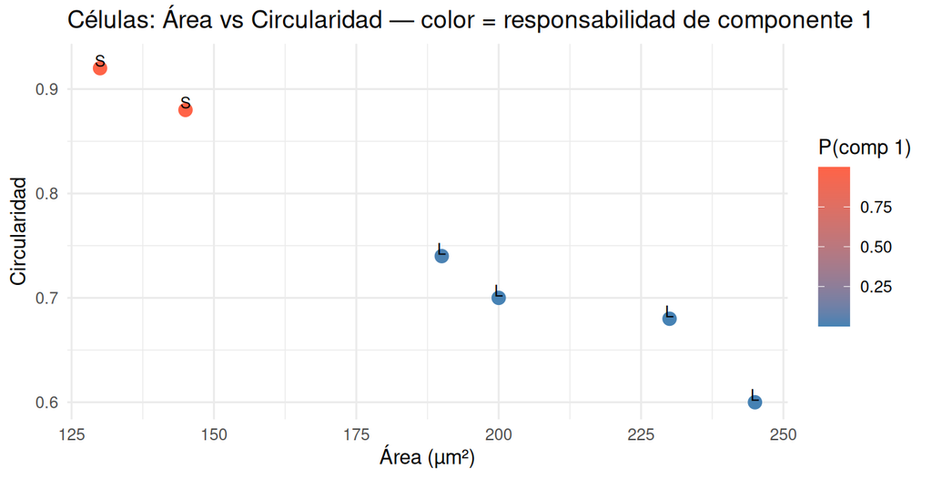

```r
library(ggplot2)

viz <- data.frame(DF, truth = truth, gamma1 = gamma1)
ggplot(viz, aes(Area, Circ)) +
  geom_point(aes(color = gamma1), size = 3) +
  geom_text(aes(label = truth), nudge_y = 0.007, size = 3) +
  scale_color_gradient(name = "P(comp 1)", low = "steelblue", high = "tomato") +
  labs(title = "Células: Área vs Circularidad — color = responsabilidad de componente 1",
       x = "Área (µm²)", y = "Circularidad") +
  theme_minimal()
```

# Confirmación con `mclust` y ARI

Usamos `Mclust` para ajustar un GMM **2D** automáticamente (elige $G$ con BIC) y comparamos con la **verdad terreno** mediante **ARI** (Adjusted Rand Index).

```r
# install.packages("mclust")  # si hace falta
library(mclust)
fit <- Mclust(X, G = 1:3)           # selección de G por BIC
summary(fit)
```

```
## ----------------------------------------------------
## Gaussian finite mixture model fitted by EM algorithm
## ----------------------------------------------------
##
## Mclust EEE (ellipsoidal, equal volume, shape and orientation) model with 3
## components:
##
##  log-likelihood n df       BIC       ICL
##       -6.246555 6 11 -32.20246 -32.20246
##
## Clustering table:
## 1 2 3
## 2 2 2
```

```r
pred <- factor(fit$classification)
table(truth, pred)
```

```
##      pred
## truth 1 2 3
##     L 0 2 2
##     S 2 0 0
```

```r
# ARI (1 = concordancia perfecta; 0 = aleatorio; <0 peor que aleatorio)
ARI <- adjustedRandIndex(truth, pred)
ARI
```

```
## [1] 0.4444444
```

# Ejercicios sugeridos

1. Repite **E-step** con $(\pi,\mu,\Sigma)$ **actualizados** para confirmar que la **log-verosimilitud** vuelve a aumentar.
2. Cambia la **inicialización** (por ejemplo, $\pi_1=0.7,\ \pi_2=0.3$ o medias más cercanas) y discute el impacto en las responsabilidades de los puntos frontera.
3. Permite $\Sigma_k$ **no diagonal** (usa `Mclust` y compara BIC entre modelos `EEE`, `VVV`, etc.).
4. Genera un **dataset sintético** mayor con dos gaussianas 2D (100–200 puntos) y repite el flujo: responsabilidades “suaves”, log-verosimilitud vs iteraciones, ARI.

Prepara un **dataset sintético** grande (con control de solapamiento) y una **lámina** de clase (PDF) con las fórmulas del EM y el mapa de responsabilidades.